# User Guide

Kenneth Condon

2018-04-20

# 1 Introduction

This package is an adaptable and efficient implementation of the tau specificity algorithm[^1] benchmarked in 2016 by Kryuchkova-Mostacci & Robinson-Rechavi[^2]. To utilise this downstream RNA-seq analysis step, the user first runs their own RNA-seq analysis pipeline and normalisation steps to produce a set of counts (e.g. FPKM, RPKM, TPM) for each gene in each tissue according to the user preference. Many algorithms have been developed for measuring tissue specificity, and they all fall into 1 of 2 categories:

- Algorithms that reduce the tissue specificity of a gene to a single value as a global measure of the gene’s specificity
- Algorithms that reduce the tissue specificity of a gene to a set of values, 1 per tissue, as a profile of the specificity of a gene for each tissue

The tau specificity algorithm was implemented in this package because:

- Tau is consistently robust
- Tau results between different data set sizes show the highest correlation
- Tau does not show bias toward finding housekeeping genes
- Tau finds the greatest number of tissue specific genes
- Enrichment analysis shows that the functions of those tissue specific genes found only by tau are consistent with the functions of the tissues in which they are found

Using both human and mouse RNA-seq data, the benchmark paper compared 9 algorithms:

- Raw counts
- Tau[^3]
- Gini coefficient (adapted from economics theory)
- Tissue specificity index (TSI)[^4]
- Shannon entropy (Hg)[^5]
- Z-score[^6]
- Specificity measure (SPM)[^7]
- Expression enrichment (EE)[^8]
- Preferential expression measure (PEM)[^9].

- 0-0.2 tissue specificity (non/low specificity, housekeeping genes)
- 0.2-0.8 tissue specificity (intermediate specificity)
- 0.8-1.0 tissue specificity (high/absolute specificity)

The authors identified the best performing algorithms as tau, gini and counts. However the authors state that counts is only robust if the correct expression threshold/cut-off is chosen and gini doesn’t normalise for expression amplitude between tissues, while tau normalises for amplitude between tissues and also includes the number of tissues as part of the algorithm.

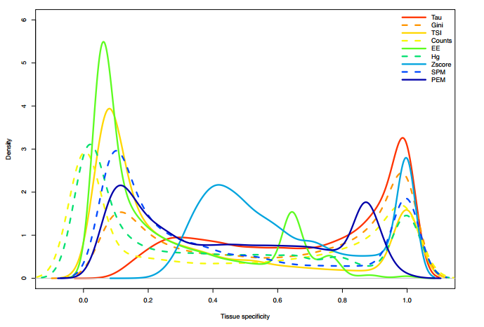

Figure 1: Distribution of tissue specificity by algorithm used.

The key conclusions of the benchmark were as follows:

- Tau showed the strongest correlation between results regardless of tissue numbers included
- Of the 9 algorithms compared in the benchmark paper, only tau avoided a bias toward classifying most genes as housekeeping and as a possible consequence, tau identified the most tissue specific genes including genes not detected by any other algorithm
- Gene Ontology enrichment suggests the extra tissue specific genes found by tau were due to false negatives in other algorithms rather than false positives in tau
- Additionally, the authors compared the effect of calculating tissue specificity using RPKM values or log transformed values and found:
  - Using RPKM detects more tissue specificity to the extent that the 0-0.2 tissue specificity group (housekeeping genes) may be lost completely
  - Using RPKM reduces correlation between both between tissue subsets and between species.

# 2 Workflow

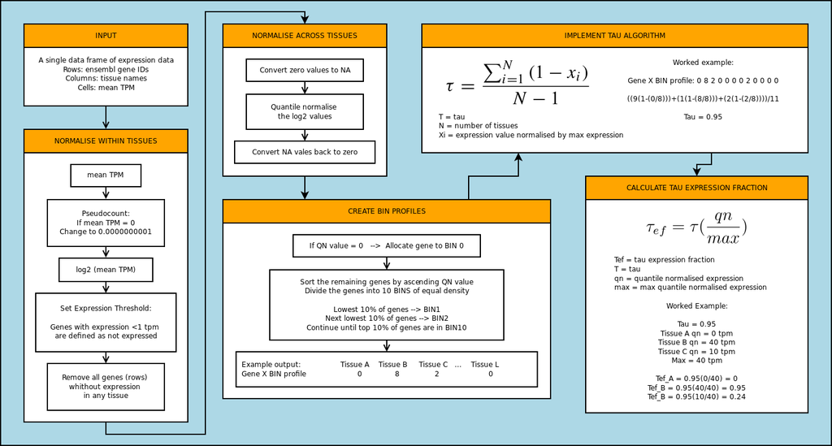

Figure 2: Calculating tissue specificity

## 2.1 Input

Users run their preferred RNA-seq analysis pipeline to calculate a single expression value for each gene in each tissue (e.g. mean TPM). Currently the package supports data from mouse, human and macaque. All genes should named by their Ensembl Gene IDs (e.g. ENSMUSG00000066232). This is to allow biomaRt annotation later in the workflow. Take care to annotate all genes using the same ensembl version (all versions from ensembl 79 onward are supported). This is important to ensure no genes are excluded from the pipeline due to discontinued Ensembl Gene IDs. The package takes as input a single dataframe where the first column is the Ensembl Gene ID, each subsequent column header is a tissue name, and the cells contain the user defined expression values of all genes in all tissues.

```r
library(tispec)
head(meanExp[,1:5], n=5)
>                      tissueA   tissueB   tissueC   tissueD   tissueE
> ENSMUSG00000014301 3.6301193 2.0391600 1.4472250 1.8513800 0.5247505
> ENSMUSG00000073609 0.0000000 0.0000000 0.0000000 0.0000000 0.0000000
> ENSMUSG00000020928 6.0836047 0.2638565 0.9679230 0.1412985 1.0217450
> ENSMUSG00000018102 5.4114287 0.3318635 0.0383125 0.0883085 0.1128075
> ENSMUSG00000021986 0.1242874 0.0308725 0.0708935 0.0878305 0.0089120
```

## 2.2 Normalisation

```r
log2Exp <- log2Tran(meanExp)
```

```r
head(log2Exp[,1:5], n=5)
>                      tissueA  tissueB   tissueC  tissueD    tissueE
> ENSMUSG00000014301 1.8600170 1.027975 0.5332892 0.888601 0.00000000
> ENSMUSG00000020928 2.6049264 0.000000 0.0000000 0.000000 0.03103518
> ENSMUSG00000018102 2.4360095 0.000000 0.0000000 0.000000 0.00000000
> ENSMUSG00000057836 0.1464763 0.000000 0.0000000 0.000000 0.00000000
> ENSMUSG00000031200 2.9537600 1.964720 1.1524982 1.384296 0.24553826
```

```r
qnExp <- quantNorm(log2Exp)
```

```r
head(qnExp[,1:5], n=5)
>                    tissueA tissueB tissueC tissueD tissueE
> ENSMUSG00000014301   2.058   1.077   0.503   1.052   0.000
> ENSMUSG00000020928   2.899   0.000   0.000   0.000   0.035
> ENSMUSG00000018102   2.695   0.000   0.000   0.000   0.000
> ENSMUSG00000057836   0.161   0.000   0.000   0.000   0.000
> ENSMUSG00000031200   3.303   2.153   1.054   1.623   0.273
```

## 2.3 Calculate Tissue Specificity

After normalisation, implementation of the tau specificity algorithm assigns each gene a tau value between 0-1.

- Absolutely specific genes (ASGs):
  - Genes expressed in a single tissue only
  - Defined by a tau value of 1
- Highly specific genes (HSGs):
  - Genes with relatively highly enriched expression in a few tissues
  - Defined by a tau value of at least 0.85.
- Housekeeping genes:
  - Genes expressed in many (or all) tissues with no enriched expression
  - Defined by a tau value of at most 0.2.

The tau value only defines the “specificity” of a gene. To determine which tissue the gene is actually specific for, requires calculation of tau expression fractions (Tef). As can be seen in the worked example in figure 2, gene X is a HSG with a tau value of 0.95. However, calculating Tef identifies that Gene X is highly specific for tissue B (0.95 Tef), with additional but much lower specificity for tissue C (0.24 Tef). Targetting gene X in tissue B, may produce off-target effects in tissue C.

```r
tauExp <- calcTau(qnExp)
```

```r
head(tauExp[,1:5], n=5)
>                      tau tissueA tissueB tissueC tissueD
> ENSMUSG00000000001 0.587   0.467   0.291   0.020   0.445
> ENSMUSG00000000003 0.911   0.000   0.000   0.000   0.000
> ENSMUSG00000000028 0.714   0.018   0.458   0.391   0.086
> ENSMUSG00000000031 1.000   0.000   0.000   0.000   0.000
> ENSMUSG00000000037 0.964   0.000   0.000   0.000   0.000
```

The output of ‘calcTau’ now begins with an extra column containing the tau value of each gene, while each tissue column is now populated with tau expression fractions.

## 2.4 Biomart Annotation

Next, using the biomaRt package, the gene name and type are added to each ensembl gene ID.

```r
tauAnno <- getMart(x = 'mouse', y = 79, z = tauExp)
```

```r
head(tauAnno[,1:5], n=5)
>                    external_gene_name   gene_biotype   tau tissueA tissueB
> ENSMUSG00000000001              Gnai3 protein_coding 0.587   0.467   0.291
> ENSMUSG00000000003               Pbsn protein_coding 0.911   0.000   0.000
> ENSMUSG00000000028              Cdc45 protein_coding 0.714   0.018   0.458
> ENSMUSG00000000031                H19        lincRNA 1.000   0.000   0.000
> ENSMUSG00000000037              Scml2 protein_coding 0.964   0.000   0.000
```

The data frame output now contains all the information required and allows easy user interaction with the following functions.

# 3 Additional Useful Functions

## 3.1 Plot the density distribution of tissue specific genes

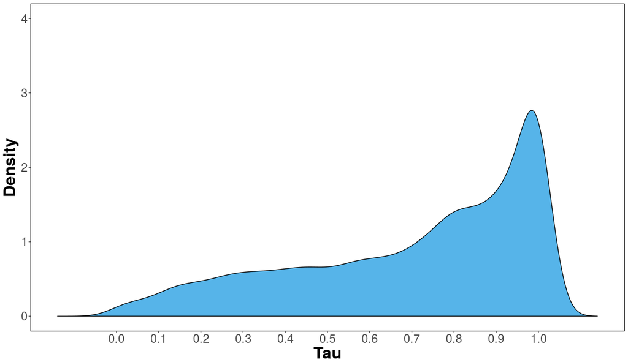

```r
plotDensity(tauAnno)
```

## 3.2 Get/Plot the number of tissue specific genes by tissue

```r
asg <- getDist(tauAnno, 1)
head(asg, n = 5)
>         protein_coding miRNA lincRNA total
> tissueA            253     8       0   261
> tissueB             14     0       0    14
> tissueC             36     0       0    36
> tissueD              0     0       0     0
> tissueE             31     0       0    31

hsg <- getDist(tauAnno, 0.85)
head(hsg, n = 5)
>         protein_coding miRNA lincRNA total
> tissueA            894    17       0   911
> tissueB            162     1       0   163
> tissueC            232     2       0   234
> tissueD             33     0       0    33
> tissueE            131     2       0   133
```

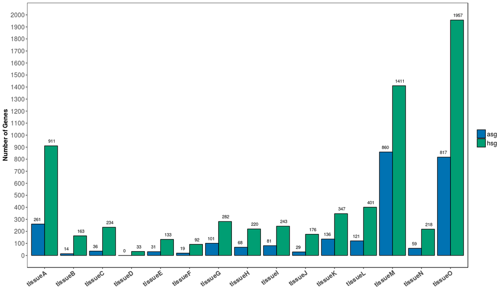

```r
plotDist(tauAnno)
```

## 3.3 Extract a tissue of interest

```r
tissueA <- getTissue('tissueA', qnExp, tauAnno)
```

```r
head(tissueA, n = 5)
>                    external_gene_name   gene_biotype    qn   tau  frac
> ENSMUSG00000000001              Gnai3 protein_coding 2.824 0.587 0.467
> ENSMUSG00000000003               Pbsn protein_coding 0.000 0.911 0.000
> ENSMUSG00000000028              Cdc45 protein_coding 0.030 0.714 0.018
> ENSMUSG00000000031                H19        lincRNA 0.000 1.000 0.000
> ENSMUSG00000000037              Scml2 protein_coding 0.000 0.964 0.000
```

The function getTissue retrieves the quantile normalised expression and tissue specificity of every gene in a named tissue. Notice H19 is an absolutely specific gene (ASG, tau 1) and is not expressed in this tissue (qn 0). Likewise Pbsn is a highly specific gene (HSG, tau 0.911) and is also not expressed in this tissue (qn 0). To identify for which tissues those genes are specific requires the plotGene function. However, organising the data like this multiple other useful functions: plotCorr, plotTop, and getControls.

### 3.3.1 Plot correlation between specificity and expression

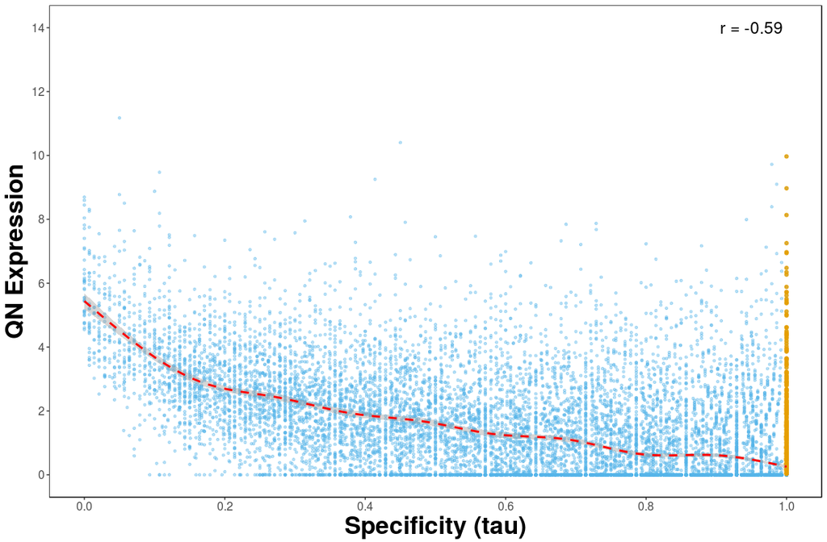

```r
corrPlots <- plotCorr(tissueA)
corrPlots$global
corrPlots$local
```

There is a negative correlation (r = -0.59) as reflected in the trendline. As the specificity of a gene **for ANY tissue** increases, the expression of the gene in tissueA decreases. However, many tissueA absolutely specific genes (orange) still have relatively high expression.

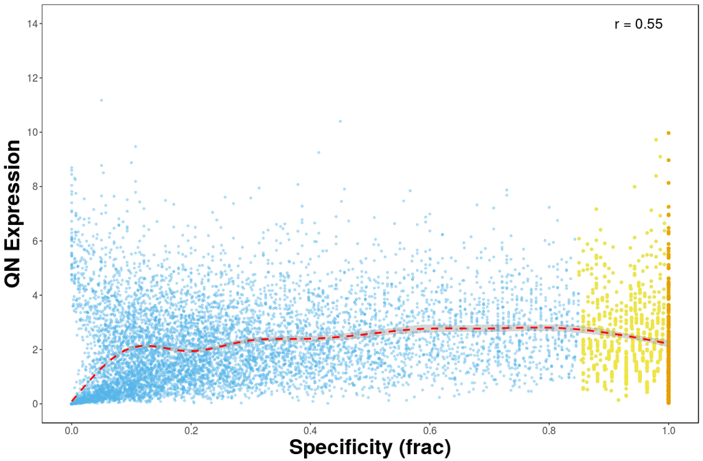

There is a positive correlation (r = 0.55). However, the trendline shows an initial strong positive correlation that plateaus from 0.1 specificity (frac). As specificity of a gene **for tissueA** increases above 0.1, there is little effect on expression. This is clearly shown by the wide range of expression of genes that are absolutely specific (orange) or highly specific (yellow) for tissueA. To get genes that are both highly specific and highly expressed use plotTop.

### 3.3.2 Plot the tissue specific genes that are also highly expressed

Ranking of genes by both expression and specificity is useful for anyone working on a single tissue wanting to identify a set of genes that are both 1) highly specific to the tissue, and 2) expressed in high enough quantities to make assaying them easier:

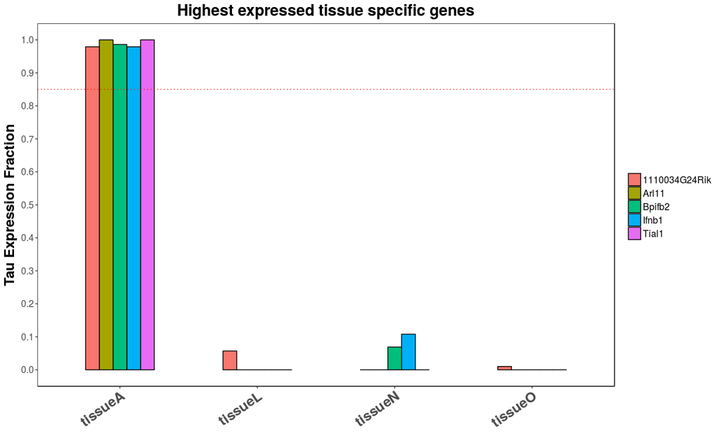

```r
plotTop(tauAnno, tissueA, 5)
```

The plot shows the top 5 expressed highly specific genes for tissueA. The plot also shows all other tissues in which those genes are expressed so as to facilitate prediction of potential off target affects of any biological experiments (e.g. CRISPR).

### 3.3.3 getControls

```r
controls <- getControls(tissueA, tissueB)
head(controls$tissueA, n = 5)
>                    external_gene_name   gene_biotype    qn   tau  frac
> ENSMUSG00000043157              Arl11 protein_coding 9.970 1.000 1.000
> ENSMUSG00000044991      1110034G24Rik protein_coding 9.722 0.979 0.979
> ENSMUSG00000027481             Bpifb2 protein_coding 9.099 0.986 0.986
> ENSMUSG00000030846              Tial1 protein_coding 8.972 1.000 1.000
> ENSMUSG00000048806              Ifnb1 protein_coding 8.393 0.979 0.979
```

The genes listed are either highly or absolutely specific for tissueA, with quantile normalised expression less than 0.1 in tissue B. This is useful for getting a set of control genes to differentiate between two tissues.

## 3.4 Extract/Plot the tissue specificity of a gene of interest

```r
subset(tauAnno, tauAnno$external_gene_name == 'Gnai3') # gene name is case sensitive
>                    external_gene_name   gene_biotype   tau tissueA tissueB
> ENSMUSG00000000001              Gnai3 protein_coding 0.587   0.467   0.291
>                    tissueC tissueD tissueE tissueF tissueG tissueH tissueI
> ENSMUSG00000000001    0.02   0.445       0   0.587   0.433   0.209   0.243
>                    tissueJ tissueK tissueL tissueM tissueN tissueO
> ENSMUSG00000000001       0       0   0.416       0       0   0.561
```

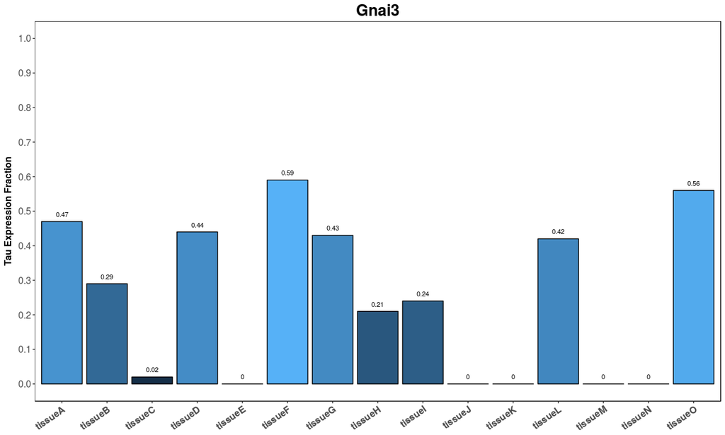

```r
plotGene(tauAnno, 'Gnai3')
```

[^1]: Yanai, I., Benjamin, H., Shmoish, M., Chalifa-Caspi, V., Shklar, M., Ophir, R., Bar-Even, A., Horn-Saban, S., Safran, M., Domany, E., Lancet, D., Shmueli, O., 2005. Genome-wide midrange transcription profiles reveal expression level relationships in human tissue specification. Bioinformatics (Oxford, England). 21, 650-659.
[^2]: Kryuchkova-Mostacci, N. & Robinson-Rechavi, M., 2016. A benchmark of gene expression tissue-specificity metrics. Briefings in Bioinformatics.
[^3]: Yanai, I., Benjamin, H., Shmoish, M., Chalifa-Caspi, V., Shklar, M., Ophir, R., Bar-Even, A., Horn-Saban, S., Safran, M., Domany, E., Lancet, D., Shmueli, O., 2005. Genome-wide midrange transcription profiles reveal expression level relationships in human tissue specification. Bioinformatics (Oxford, England). 21, 650-659.
[^4]: Julien, P., Brawand, D., Soumillon, M., Necsulea, A., Liechti, A., Schutz, F., Daish, T., Grutzner, F., Kaessmann, H., 2012. Mechanisms and evolutionary patterns of mammalian and avian dosage compensation. PLoS Biology. 10, e1001328.
[^5]: Schug, J., Schuller, W.P., Kappen, C., Salbaum, J.M., Bucan, M., Stoeckert, C.J.,Jr, 2005. Promoter features related to tissue specificity as measured by Shannon entropy. Genome Biology. 6, R33.
[^6]: Vandenbon, A. & Nakai, K., 2010. Modeling tissue-specific structural patterns in human and mouse promoters. Nucleic Acids Research. 38, 17-25.
[^7]: Xiao, S.J., Zhang, C., Zou, Q., Ji, Z.L., 2010. TiSGeD: a database for tissue-specific genes. Bioinformatics (Oxford, England). 26, 1273-1275.
[^8]: Yu, X., Lin, J., Zack, D.J., Qian, J., 2006. Computational analysis of tissue-specific combinatorial gene regulation: predicting interaction between transcription factors in human tissues. Nucleic Acids Research. 34, 4925-4936.
[^9]: Huminiecki, L., Lloyd, A.T., Wolfe, K.H., 2003. Congruence of tissue expression profiles from Gene Expression Atlas, SAGEmap and TissueInfo databases. BMC Genomics. 4, 31.